# MSCA 31008 HW3-Part1

Ruoxin Shi

2022/2/2

## Latent Class Analysis

### Load Data

```r
# load data
GermanCredit <- read.table("http://archive.ics.uci.edu/ml/machine-learning-databases/statlog/german/german.data", stringsAsFactors = TRUE)

colnames(GermanCredit) <- c("CheckingAccountStatus", "Duration", "CreditHistory", "Purpose", "Amount",  "SavingsAccountBonds", "EmploymentDuration", "InstallmentRatePercentage",  "Personal",  "OtherDebtorsGuarantors", "ResidenceDuration", "Property",  "Age",  "OtherInstallmentPlans", "Housing", "NumberExistingCredits", "Job", "NumberPeopleMaintenance", "Telephone", "ForeignWorker", "Class")
```

```r
# Select only categorical vairable for segmentation use
# Delete unrelated variables
non_categorical_vars <- c('Duration', 'CreditHistory', 'Amount', 'EmploymentDuration',
                          'InstallmentRatePercentage', 'OtherDebtorsGuarantors',
                          'ResidenceDuration', 'Age', 'OtherInstallmentPlans',
                          'NumberExistingCredits', 'NumberPeopleMaintenance',
                          'Telephone', 'ForeignWorker', 'Class')
data <- GermanCredit[,!(names(GermanCredit) %in% non_categorical_vars)]
data[is.na(data)] <- "NA"
```

### Attribute Information:

**CheckingAccountStatus**  
A11 : … < 0 DM  
A12 : 0 <= … < 200 DM  
A13 : … >= 200 DM / salary assignments for at least 1 year  
A14 : no checking account

**Purpose**  
A40 : car (new)  
A41 : car (used)  
A42 : furniture/equipment  
A43 : radio/television  
A44 : domestic appliances  
A45 : repairs  
A46 : education  
A47 : (vacation - does not exist?)  
A48 : retraining  
A49 : business  
A410 : others

**Savings account/bonds**  
A61 : … < 100 DM  
A62 : 100 <= … < 500 DM  
A63 : 500 <= … < 1000 DM  
A64 : .. >= 1000 DM  
A65 : unknown/ no savings account

**Personal**  
A91 : male : divorced/separated  
A92 : female : divorced/separated/married  
A93 : male : single  
A94 : male : married/widowed  
A95 : female : single

**Property**  
A121 : real estate  
A122 : if not A121 : building society savings agreement/ life insurance  
A123 : if not A121/A122 : car or other, not in attribute 6  
A124 : unknown / no property

**Job**  
A171 : unemployed/ unskilled - non-resident  
A172 : unskilled - resident  
A173 : skilled employee / official  
A174 : management/ self-employed/  
highly qualified employee/ officer

### Split Data into Train and Test Set

```r
# make result reproducible
set.seed(1123)

sample_size <- round(0.7 * nrow(data))

train_ind <- sample(seq_len(nrow(data)), size = sample_size)
train <- data[train_ind, ]
test <- data[-train_ind, ]
```

### Try Different k values. (Save AIC and BIC)

```r
library(poLCA)
f <- cbind(CheckingAccountStatus, Purpose,
                     SavingsAccountBonds,Personal,
                     Property, Job) ~ 1
AIC <- data.frame()
BIC <- data.frame()

for (i in 2:6) {
  lca <- poLCA(f, train, nclass = i, tol=0.001, nrep=10, verbose = FALSE)
  AIC <- rbind(AIC, cbind(i, lca$aic))
  BIC <- rbind(BIC, cbind(i, lca$bic))
}
```

```r
names(AIC) <- c("num_of_classes", "aic")
names(BIC) <- c("num_of_classes", "bic")
result <- data.frame(cbind(AIC, BIC$bic))
names(result) <- c("num_of_classes", "aic", "bic")
```

### Plot the Scree Plot of AIC/BIC for Different k

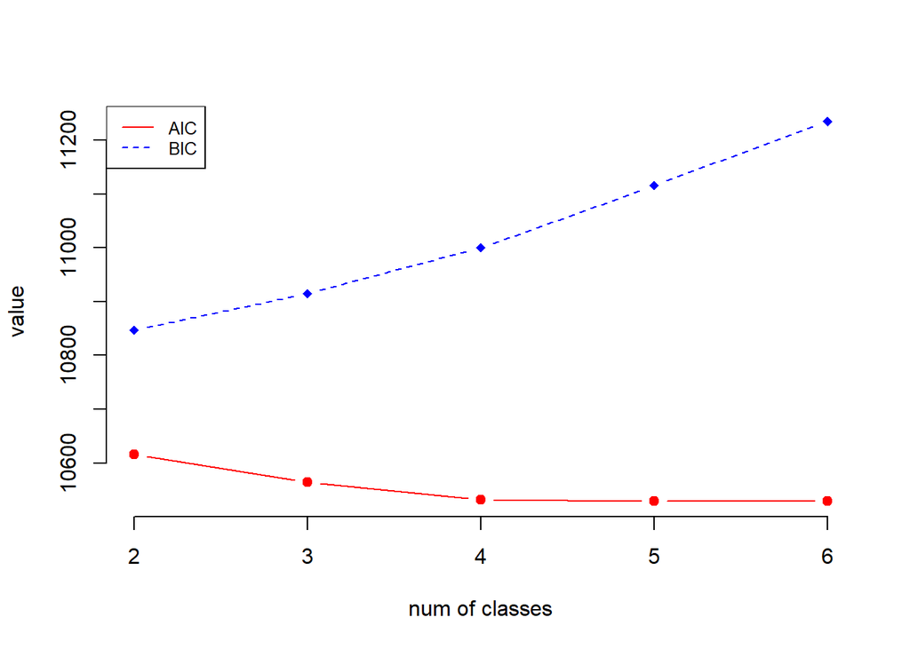

```r
# Create a first line
plot(result$num_of_classes, result$aic, type = "b", frame = FALSE, pch = 19,
     col = "red", ylim =range(min(result$aic, result$bic), max(result$aic, result$bic)),
     xlab = "num of classes", ylab = "value")
# Add a second line
lines(result$num_of_classes, result$bic, pch = 18, col = "blue", type = "b", lty = 2)
# Add a legend to the plot
legend("topleft", legend=c("AIC", "BIC"), col=c("red", "blue"), lty = 1:2, cex=0.8)
```

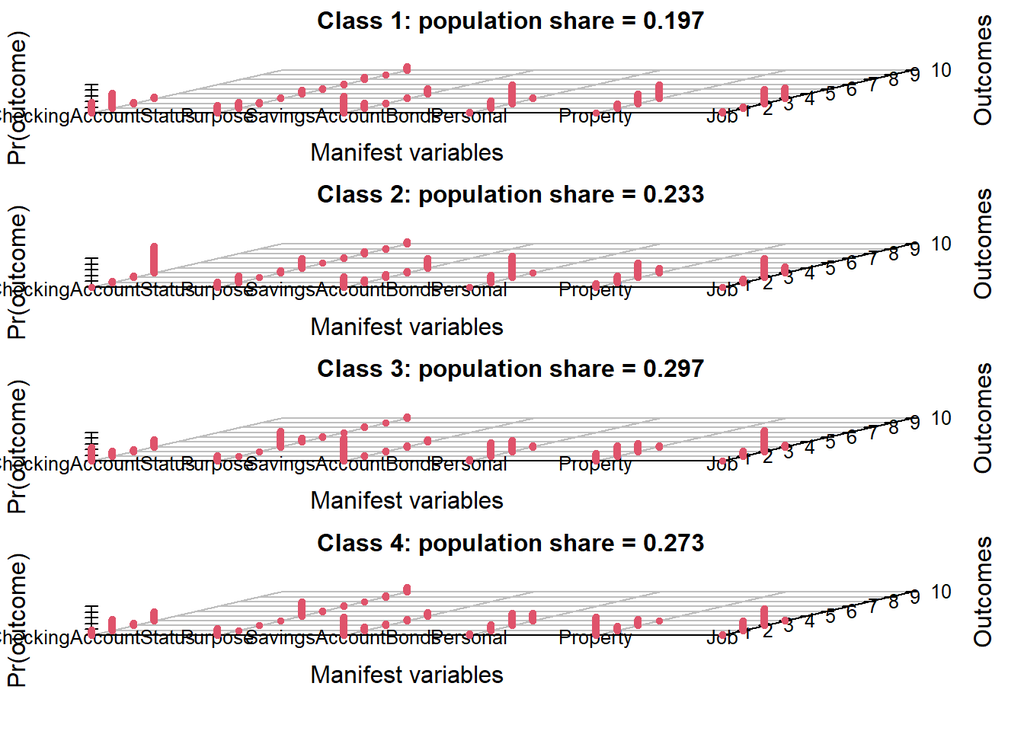

```r
lca_4class <- poLCA(f, train, nclass = 4, tol=0.001, nrep=10, verbose = FALSE, graphs = TRUE)
```

```r
train_probs <- lca_4class$probs
```